# Women Techsters Fellowship 2021

## Group 3 Mini-project

### Proposal for NLP Search Engine APP

Development Team 1. Joy Kareko - Group Leader 2. Ruth Waiharo 3. Anita Mburu 4. Esther Anagu 5. Lilian Adhiambo 6. Ajiboye Azeezat 7. Florence Wangeci 8. Juliet Nelly 9. Nelly Nyaga

# Project Goals, Scope and Functionality

# Problem

Virtual assistants powered by artificial intelligence have become a commmon feature of the big-data revolution.

Cortana, Google assistant, and Siri are some of the most popular assistants available on mobile devices and PCs. These assistants which primarily take natural voice as the input have been instrumental for children, people with disabilites and all users in general.

While the available ones have excellent utility, gaps are still available to build specific and tailor made assitants because the "one-size-fits-all" does not always apply.

In this project we sought to find out how Search Engines with text to speech and speech to text functionalities work and then we sought to build our very own search engine complete with a voice capturing capability, display ability as well as a user interface.

The search engine used Speech to text capabilities and displayed the same using Tkinter, a Graphical User Interface available on Python hence the name Tkinter_search Engine.

## Goals

OVERALL OBJECTIVE

The objective is to have an NLP search engine that outputs results for any search. The search engine will be enabled to recognize speech and text effciently with regard to grammar and different accents.

SPECIFIC OBJECTIVES

1. Understand NLP work
2. Build a text to speech functionality
3. Build a speech to text functionality
4. Define and process Keywords using NLP python package
5. Visualize results through a GUI on Tkinter

## Development method

While we have a limited timeframe, we will adopt the agile approach where we will consult users and team members at sprint/cycle to ger new insights and ideas into improving our product. The agile method is illustrated below.

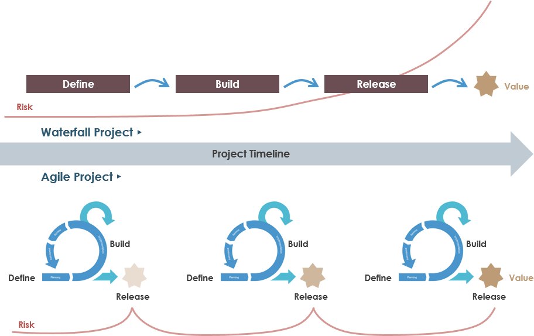

## Tools

1. Jupyter notebook - code,writeup
2. NLP
3. Python Libraries such as tkinter, speech recognition, Google Text to speech among others.
4. Youtube videos
5. Data science sites- geeks4geeks, Kaggle, codecademy, datacamp, analytics vidhya

## Prototype screenshots

### Product 1

[figure not shown]

### Product 2

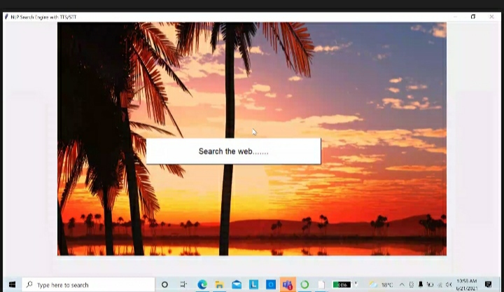

### Showing how it works(Sample input and Output)

Speech: What is your name? Response from Tkinter Search: "My name is Siri"

Speech: Show me Response from Tkinter Search: What do you want to see?

```
    Speeech: Pictures of cats

        Response from Tkinter Search: Results for cats (Opens URL)
```

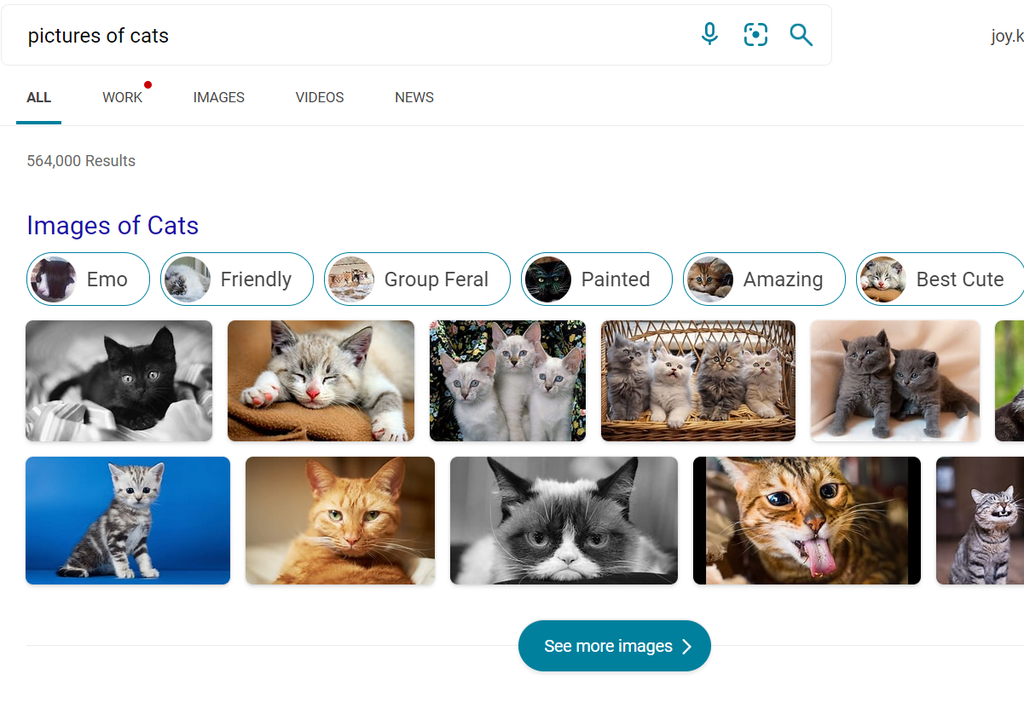

### WomenWhoCode-Group Photo

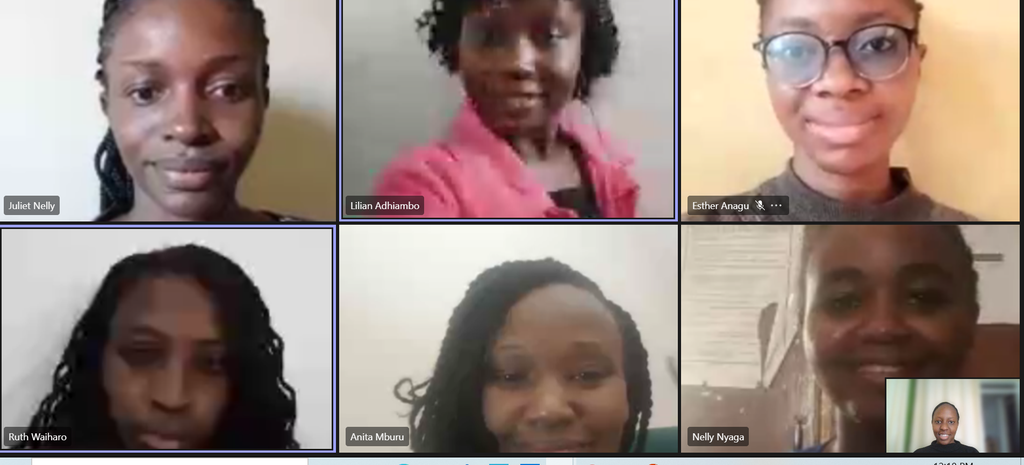

### Recommendations

We will continue to modify code and make the output even better, over time as we get more exposure to make look like a Google of Microsoft Bing Search Engine over time.

### References

1. https://www.kaggle.com/
2. https://www.analyticsvidhya.com/
3. https://www.datacamp.com/
4. https://www.youtube.com/watch?v=IWDC9vcBIFQ